# RBIF112 - Final Assignment

## 2.3 Principal Component Analysis

Principal component analysis was performed using the (normalized) expression data based on the results of variance analysis above and after filtering out the low variance genes.

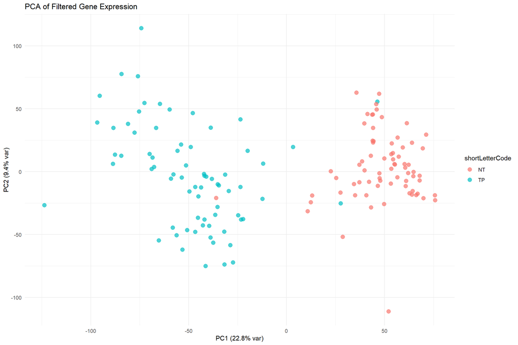

```r
library(ggplot2)

# 1. get the expression matrix (normalized)
expr_norm3 <- expr_norm[rownames(var_df2), ]

# 2. scale the data
expr_scaled <- t(scale(t(expr_norm3)))
# transpose the expression matrix
expr_transpose <- t(expr_scaled)

# 3. perform PCA
pca_result <- prcomp(expr_transpose, scale. = FALSE)

# 4. prepare data for plotting
# create a data frame from the PCA results and the sample attributes
pca_df <- data.frame(pca_result$x,
                     colData(SECoding))

# plot PCA colored by a sample attribute (e.g. shortLetterCode)
# aes() function is used to map the variables to the x and y axes
# geom_point() function is used to create a scatter plot
# theme_minimal() function is used to create a minimal theme
# labs() function is used to add labels to the plot
ggplot(pca_df, aes(x = PC1, y = PC2, color = shortLetterCode)) +
  geom_point(size = 3, alpha = 0.7) +
  theme_minimal() +
  labs(title = paste("PCA of Filtered Gene Expression"),
       x = paste0("PC1 (", round(100*summary(pca_result)$importance[2,1], 1), "% var)"),
       y = paste0("PC2 (", round(100*summary(pca_result)$importance[2,2], 1), "% var)"))
```

**Discussion:**  
Based on the PCA plot above, the first two PCs capture the largest sources of variation (~32%) in the dataset, where PC1 explains 22.8% of the total variance and PC2 explains 9.4%. The samples clearly form two distinct clusters. The right cluster (pink) is dominated by normal tissue (NT) samples, and the left cluster (blue) is dominated by primary tumor (TP) samples. The separation along PC1 is strong and consistent, indicating the largest variation in the filtered data corresponds to tumor vs. normal tissue. Only a small number appear to be mixed points and are possibly due to sample heterogeneity.  
The variance filtering was effective, reducing background noise and retaining only genes with meaningful differences. The resulting PCA show distinct clustering and enhancing the signal-to-noise. The distinct separation between NT and TP groups along PC1 shows that the filtered high-variance genes effectively captured biologically relevant signals. These genes are driving most of the expression variability, confirming that tumor samples have very different transcriptional profiles compared to normal kidney tissue.

During PCA of a gene expression matrix, PCA finds the principal components – the linear combinations of the original gene expression variables that capture the maximum variance in the data – and each PC is defined by a **loading vector**, which specifies how much each gene contributes to that principal component. A high loading value (positive or negative) means the gene strongly contributes to that component. A low loading means the gene has little influence on that PC’s direction of variance.  
Therefore, the code below will identify the PCA loads from the PCA model to extract the genes that are significantly driving the separation patterns seen in the plot. These genes will be used as the input dataset for the prediction models in subsequent analyses.

```r
# 5. find the most significant genes in PC1 and PC2
# get the loadings and make a data frame
pca_loads <- as.data.frame(pca_result$rotation)
# attach gene information to loadings
pca_loads$gene_id <- var_df2$gene_id
pca_loads$gene_name <- var_df2$gene_name

# 5.1.subset top 20 genes in PC1
pc1_gene <- pca_loads %>%
  as.data.frame() %>%
  # arrange by absolute value of PC1
  arrange(desc(PC1)) %>%
  # select the top 20 genes
  head(20) %>%
  # select the gene id, gene name, and PC1
  select(gene_id, gene_name, PC1)
# print genes in PC1
pc1_gene
```

```
##                               gene_id gene_name        PC1
## ENSG00000053770.12 ENSG00000053770.12     AP5M1 0.01743265
## ENSG00000115364.14 ENSG00000115364.14    MRPL19 0.01725965
## ENSG00000189241.8   ENSG00000189241.8    TSPYL1 0.01712774
## ENSG00000013503.10 ENSG00000013503.10    POLR3B 0.01709293
## ENSG00000114904.13 ENSG00000114904.13      NEK4 0.01699457
## ENSG00000137819.14 ENSG00000137819.14     PAQR5 0.01699078
## ENSG00000114742.14 ENSG00000114742.14     WDR48 0.01695891
## ENSG00000166908.18 ENSG00000166908.18   PIP4K2C 0.01695430
## ENSG00000100897.18 ENSG00000100897.18    DCAF11 0.01693410
## ENSG00000172113.9   ENSG00000172113.9      NME6 0.01689231
## ENSG00000136143.16 ENSG00000136143.16    SUCLA2 0.01688763
## ENSG00000162688.17 ENSG00000162688.17       AGL 0.01687380
## ENSG00000168827.15 ENSG00000168827.15      GFM1 0.01686901
## ENSG00000115109.14 ENSG00000115109.14   EPB41L5 0.01684838
## ENSG00000081026.19 ENSG00000081026.19     MAGI3 0.01684446
## ENSG00000150768.16 ENSG00000150768.16      DLAT 0.01680655
## ENSG00000152234.16 ENSG00000152234.16   ATP5F1A 0.01679486
## ENSG00000185515.15 ENSG00000185515.15     BRCC3 0.01676909
## ENSG00000196482.18 ENSG00000196482.18     ESRRG 0.01675306
## ENSG00000165813.20 ENSG00000165813.20   CCDC186 0.01674806
```

```r
# 5.2.get the most significant gene in PC2
pc2_gene <- pca_loads %>%
  as.data.frame() %>%
  arrange(desc(PC2)) %>%
  head(20) %>%
  select(gene_id, gene_name, PC2)
# print genes in PC2
pc2_gene
```

```
##                               gene_id gene_name        PC2
## ENSG00000175756.13 ENSG00000175756.13  AURKAIP1 0.02551515
## ENSG00000125901.6   ENSG00000125901.6    MRPS26 0.02491443
## ENSG00000170906.16 ENSG00000170906.16    NDUFA3 0.02473043
## ENSG00000126768.12 ENSG00000126768.12   TIMM17B 0.02454236
## ENSG00000133265.11 ENSG00000133265.11    HSPBP1 0.02453248
## ENSG00000099795.7   ENSG00000099795.7    NDUFB7 0.02449803
## ENSG00000145494.12 ENSG00000145494.12    NDUFS6 0.02439573
## ENSG00000140365.16 ENSG00000140365.16    COMMD4 0.02433357
## ENSG00000204237.5   ENSG00000204237.5     OXLD1 0.02390166
## ENSG00000141552.18 ENSG00000141552.18   ANAPC11 0.02385403
## ENSG00000174917.9   ENSG00000174917.9   MICOS13 0.02378289
## ENSG00000110717.13 ENSG00000110717.13    NDUFS8 0.02375353
## ENSG00000126432.14 ENSG00000126432.14     PRDX5 0.02365393
## ENSG00000140990.15 ENSG00000140990.15   NDUFB10 0.02362692
## ENSG00000086504.17 ENSG00000086504.17    MRPL28 0.02359498
## ENSG00000172590.18 ENSG00000172590.18    MRPL52 0.02358873
## ENSG00000167969.13 ENSG00000167969.13      ECI1 0.02357017
## ENSG00000177700.6   ENSG00000177700.6    POLR2L 0.02353891
## ENSG00000131143.10 ENSG00000131143.10    COX4I1 0.02346823
## ENSG00000167770.11 ENSG00000167770.11     OTUB1 0.02342787
```

The result of loadings for PC1 shows that they are all positive and relatively close in magnitude (around 0.016-0.017), indicating that no single gene dominates PC1. Similarly for PC2, they are all positive and the magnitude are around 0.025.  
The resulting data sets from PC1 and PC2 will serve as the data input for building the models below. The genes from PC2 may be included in the model to determine whether it could improve the model performance; otherwise, it will be left out and only genes from PC1 will be included.

# 3 Model Development

The codes below will define the outcome variable, prepare the expression data for modeling based on the PCA loadings results, and define the function to assess the predictions from various models.

```r
## Define outcome variable for modeling
# create a new column in the meta data frame with the outcome
# if the sample type is tumor the outcome is 1, otherwise it's 0
meta$kidney_cancer <- ifelse(grepl("Tumor", meta$sample_type, ignore.case = TRUE), 1, 0)

# count the number of 1s and 0s in the outcome to check balance
table(meta$kidney_cancer)
```

```
##
##  0  1
## 72 72
```

```r
# convert data frame to a factor
outcome <- meta$kidney_cancer
outcome <- factor(outcome, levels = c(0,1))
head(outcome)
```

```
## [1] 1 1 1 1 1 1
## Levels: 0 1
```

```r
## Prepare data for modeling ##
# get the genes from PCA
# need matrix array as input for logistic regression
pc1_mat <- expr_transpose[, pc1_gene$gene_id]
pc1_mat[1:2, 1:5]
```

```
##                              ENSG00000053770.12 ENSG00000115364.14
## TCGA-CZ-4861-01A-01R-1305-07         -1.0419171         -0.5823893
## TCGA-BP-4353-01A-02R-1289-07         -0.7839628         -0.6106992
##                              ENSG00000189241.8 ENSG00000013503.10
## TCGA-CZ-4861-01A-01R-1305-07        -0.5083269         -0.9873117
## TCGA-BP-4353-01A-02R-1289-07        -1.5045039         -0.9434869
##                              ENSG00000114904.13
## TCGA-CZ-4861-01A-01R-1305-07         -0.4431955
## TCGA-BP-4353-01A-02R-1289-07         -0.2745939
```

```r
pc2_mat <- expr_transpose[, pc2_gene$gene_id]
pc2_mat[1:2, 1:5]
```

```
##                              ENSG00000175756.13 ENSG00000125901.6
## TCGA-CZ-4861-01A-01R-1305-07         -0.5549452        -0.6869558
## TCGA-BP-4353-01A-02R-1289-07         -1.6991432        -1.7339477
##                              ENSG00000170906.16 ENSG00000126768.12
## TCGA-CZ-4861-01A-01R-1305-07         -0.9523525         -0.7286275
## TCGA-BP-4353-01A-02R-1289-07         -1.0732902         -1.9634575
##                              ENSG00000133265.11
## TCGA-CZ-4861-01A-01R-1305-07         -0.5002497
## TCGA-BP-4353-01A-02R-1289-07         -1.6943121
```

```r
# need data frame as input for the rest of the models
df_pc1 <- as.data.frame(expr_transpose[, pc1_gene$gene_id])
df_pc1[1:2, 1:5]
```

```
##                              ENSG00000053770.12 ENSG00000115364.14
## TCGA-CZ-4861-01A-01R-1305-07         -1.0419171         -0.5823893
## TCGA-BP-4353-01A-02R-1289-07         -0.7839628         -0.6106992
##                              ENSG00000189241.8 ENSG00000013503.10
## TCGA-CZ-4861-01A-01R-1305-07        -0.5083269         -0.9873117
## TCGA-BP-4353-01A-02R-1289-07        -1.5045039         -0.9434869
##                              ENSG00000114904.13
## TCGA-CZ-4861-01A-01R-1305-07         -0.4431955
## TCGA-BP-4353-01A-02R-1289-07         -0.2745939
```

```r
df_pc2 <- as.data.frame(expr_transpose[, pc2_gene$gene_id])
df_pc2[1:2, 1:5]
```

```
##                              ENSG00000175756.13 ENSG00000125901.6
## TCGA-CZ-4861-01A-01R-1305-07         -0.5549452        -0.6869558
## TCGA-BP-4353-01A-02R-1289-07         -1.6991432        -1.7339477
##                              ENSG00000170906.16 ENSG00000126768.12
## TCGA-CZ-4861-01A-01R-1305-07         -0.9523525         -0.7286275
## TCGA-BP-4353-01A-02R-1289-07         -1.0732902         -1.9634575
##                              ENSG00000133265.11
## TCGA-CZ-4861-01A-01R-1305-07         -0.5002497
## TCGA-BP-4353-01A-02R-1289-07         -1.6943121
```

```r
## Define function to assess predictions ##
assess.prediction <- function(truth,predicted) {
  # exclude NA values from predicted and truth variables
  predicted = predicted[! is.na(truth)]
  truth = truth[! is.na(truth)]
  truth = truth[! is.na(predicted)]
  predicted = predicted[! is.na(predicted)]
  # print the total number of cases that are not NA
  cat("Total cases that are not NA: ",length(truth),"\n",sep="")
  # print the correct predictions or accuracy
  cat("Correct predictions (accuracy): ",sum(truth==predicted), "(",signif(sum(truth==predicted)*100/length(truth),3),"%)\n",sep="")
  # calculate the true positive rate, true negative rate, positive predictive value,
  # false discovery rate, and false positive rate
  TP = sum(truth==1 & predicted==1)
  TN = sum(truth==0 & predicted==0)
  FP = sum(truth==0 & predicted==1)
  FN = sum(truth==1 & predicted==0)
  # calculate the total number of positive and negative cases
  P = TP+FN
  N = FP+TN
  # print the true positive rate, true negative rate, positive predictive value,
  # false discovery rate, and false positive rate.
  # report results in percentage (hence 100*) and 3 decimal places
  cat("TPR (sensitivity)=TP/P: ", signif(100*TP/P,3),"%\n",sep="")
  cat("TNR (specificity)=TN/N: ", signif(100*TN/N,3),"%\n",sep="")
  cat("PPV (precision)=TP/(TP+FP): ", signif(100*TP/(TP+FP),3),"%\n",sep="")
  cat("FDR (false discovery)=1-PPV: ", signif(100*FP/(TP+FP),3),"%\n",sep="")
  cat("FPR =FP/N=1-TNR: ", signif(100*FP/N,3),"%\n",sep="")
}
```

## 3.1 Logistic Regression

```r
## Logistic Regression ##
# takes in matrix array, not data frame
# 1. Using the genes from PC1 results
log_reg1 <- glm(outcome ~ pc1_mat, family = "binomial")
as.numeric(predict(log_reg1, type = "response") > 0.5)
```

```
##   [1] 1 1 1 1 1 1 1 1 1 1 1 1 1 1 1 1 1 1 1 1 1 1 1 1 1 1 1 1 1 1 1 1 1 1 1 1 1
##  [38] 1 1 1 1 1 1 1 1 1 1 1 1 1 1 1 1 1 1 1 1 1 1 1 1 1 1 1 1 1 1 1 1 1 1 1 0 0
##  [75] 0 0 0 0 0 0 0 0 0 0 0 0 0 0 0 0 0 0 0 0 0 0 0 0 0 0 0 0 0 0 0 0 0 0 0 0 0
## [112] 0 0 0 0 0 0 0 0 0 0 0 0 0 0 0 0 0 0 0 0 0 0 0 0 0 0 0 0 0 0 0 0 0
```

```r
assess.prediction(outcome, as.numeric(predict(log_reg1, type = "response") > 0.5))
```

```
## Total cases that are not NA: 144
## Correct predictions (accuracy): 144(100%)
## TPR (sensitivity)=TP/P: 100%
## TNR (specificity)=TN/N: 100%
## PPV (precision)=TP/(TP+FP): 100%
## FDR (false discovery)=1-PPV: 0%
## FPR =FP/N=1-TNR: 0%
```

```r
# 2. Using the top 20 most significant p-values from the t-test expression data results
log_reg2 <- glm(outcome ~ pc1_mat + pc2_mat, family = "binomial", na.action = "na.exclude")
as.numeric(predict(log_reg2, type = "response") >0.5)
```

```
##   [1] 1 1 1 1 1 1 1 1 1 1 1 1 1 1 1 1 1 1 1 1 1 1 1 1 1 1 1 1 1 1 1 1 1 1 1 1 1
##  [38] 1 1 1 1 1 1 1 1 1 1 1 1 1 1 1 1 1 1 1 1 1 1 1 1 1 1 1 1 1 1 1 1 1 1 1 0 0
##  [75] 0 0 0 0 0 0 0 0 0 0 0 0 0 0 0 0 0 0 0 0 0 0 0 0 0 0 0 0 0 0 0 0 0 0 0 0 0
## [112] 0 0 0 0 0 0 0 0 0 0 0 0 0 0 0 0 0 0 0 0 0 0 0 0 0 0 0 0 0 0 0 0 0
```

```r
assess.prediction(outcome, as.numeric(predict(log_reg2, type = "response") >0.5))
```

```
## Total cases that are not NA: 144
## Correct predictions (accuracy): 144(100%)
## TPR (sensitivity)=TP/P: 100%
## TNR (specificity)=TN/N: 100%
## PPV (precision)=TP/(TP+FP): 100%
## FDR (false discovery)=1-PPV: 0%
## FPR =FP/N=1-TNR: 0%
```

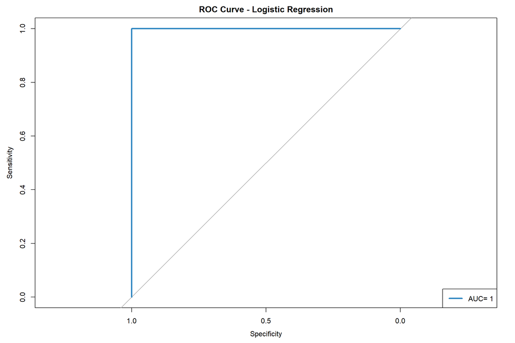

```r
# load package
library(pROC)

# get predicted probabilities, not 0/1 classification
log_reg1_probs <- predict(log_reg1, type = "response")
# create ROC curve
roc_logreg1 <- roc(outcome, log_reg1_probs)
plot(roc_logreg1, col = "#2E86C1", lwd = 3, main = "ROC Curve - Logistic Regression")
# add AUC to plot
auc_logreg1 <- auc(roc_logreg1)
legend("bottomright", legend = paste("AUC=", round(auc_logreg1, 3)), col = "#2E86C1", lwd=3)
```

**Discussion:**  
The first model perfectly classified all 144 samples using the genes from PC1 without misclassifications. Adding the second set of genes from PC2 into the second model did not change performance, since the first one was already perfect. This suggests that the genes driving PC1 already capture the main variance that distinguishes between normal vs. tumor states. Since the PCA already showed clear separation between tumor and normal groups – meaning the underlying biology is strongly separable – so a simple linear model like logistic regression might indeed perform perfectly on this dataset.

## 3.2 Neural Network

```r
library(neuralnet)

# use functions to conveniently use tilde (~) to perform neural network analysis
expand.formula = function(f,data=NULL) {
  f.str = deparse(f)
  if ( grepl("\\.$",f.str)[1] ) {
    if ( is.null(data) ) { stop("Shortcut formula ~. requires a dataframe") }
  } else {
    return(f)
  }
  dependent.name = sub("\\s*~.*","",f.str)
  n = names(data)
  n = n[ n != dependent.name ]
  rhs = paste(n,collapse=" + ")
  f.str = sub("\\.$",rhs,f.str)
  f = as.formula(f.str,env=environment(f))
  return(f)
}

neuralnet.fx = function(f,data,...) {
  f = expand.formula(f,data)
  f.str = deparse(f)
  f.str = paste(f.str,collapse="")
  dependent.name = sub("\\s*~.*","",f.str)
  if ( ! dependent.name %in% names(data) ) {
    dependent.data = get(dependent.name,envir=environment(f))
    data=cbind(dependent.data,data)
    names(data)[1] = dependent.name
  }
  has.na = apply(data,1,function(x) { any(is.na(x)) } )
  data = data[! has.na,,drop=F]
  if ( is.factor( data[,dependent.name] ) ) {
    data[,dependent.name] = as.numeric(as.vector(data[,dependent.name]))
  }
  neuralnet(f,data,...)
}

# Perform neural net analysis
# using the top 20 genes from PC1
nnet1 <- neuralnet.fx(outcome ~ ., data = df_pc1, hidden=5, linear.output=FALSE)
assess.prediction(outcome, as.numeric(compute(nnet1, df_pc1)$net.result[,1] >0.5))
```

```
## Total cases that are not NA: 144
## Correct predictions (accuracy): 143(99.3%)
## TPR (sensitivity)=TP/P: 100%
## TNR (specificity)=TN/N: 98.6%
## PPV (precision)=TP/(TP+FP): 98.6%
## FDR (false discovery)=1-PPV: 1.37%
## FPR =FP/N=1-TNR: 1.39%
```

```r
# using the top 20 genes from PC1 + PC2
nnet2 <- neuralnet.fx(outcome ~ ., data = df_pc1 + df_pc2, hidden=5, linear.output=FALSE)
assess.prediction(outcome, as.numeric(compute(nnet2, df_pc1 + df_pc2)$net.result[,1] >0.5))
```

```
## Total cases that are not NA: 144
## Correct predictions (accuracy): 143(99.3%)
## TPR (sensitivity)=TP/P: 100%
## TNR (specificity)=TN/N: 98.6%
## PPV (precision)=TP/(TP+FP): 98.6%
## FDR (false discovery)=1-PPV: 1.37%
## FPR =FP/N=1-TNR: 1.39%
```

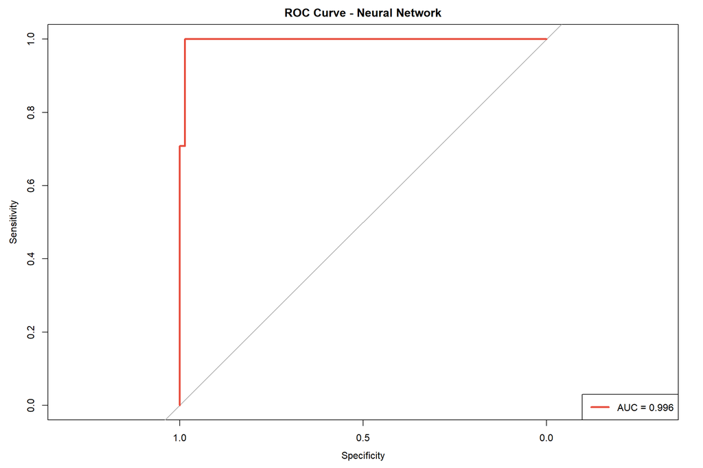

```r
# add ROC curve
# raw probabilities
nnet_pred <- as.numeric(compute(nnet1, df_pc1)$net.result[,1])
roc_nnet <- roc(outcome, nnet_pred)
plot(roc_nnet, col = "#E74C3C", lwd = 3, main = "ROC Curve - Neural Network")
auc_nnet <- auc(roc_nnet)
legend("bottomright", legend = paste("AUC =", round(auc_nnet, 3)), col = "#E74C3C", lwd = 3)
```

## 3.3 Support Vector Machine

```r
library(e1071)

# define the predict function
predict_svm = function(M,newdata,...) {
  if (inherits(M,"svm") && ! is.null(newdata)) {
    has.na = apply(newdata,1,function(x) any(is.na(x)) )
    has.data = which(! has.na);
    has.na = which( has.na)
    pred = stats::predict(M,newdata[has.data,,drop=F],...)
    pred.with.na = pred[1]
    pred.with.na[ has.data ] = pred
    pred.with.na[ has.na ] = NA
    pred.with.na
  } else {
    stats::predict(M,newdata,...)  }  }

# perform SVM based on various kernels
svm1 <- svm(outcome ~ ., df_pc1, kernel="linear", cost=1)
assess.prediction(outcome, predict(svm1, df_pc1))
```

```
## Total cases that are not NA: 144
## Correct predictions (accuracy): 143(99.3%)
## TPR (sensitivity)=TP/P: 100%
## TNR (specificity)=TN/N: 98.6%
## PPV (precision)=TP/(TP+FP): 98.6%
## FDR (false discovery)=1-PPV: 1.37%
## FPR =FP/N=1-TNR: 1.39%
```

```r
svm2 <- svm(outcome ~ ., df_pc1, kernel="polynomial", degree=3)
assess.prediction(outcome, predict(svm2, df_pc1))
```

```
## Total cases that are not NA: 144
## Correct predictions (accuracy): 141(97.9%)
## TPR (sensitivity)=TP/P: 97.2%
## TNR (specificity)=TN/N: 98.6%
## PPV (precision)=TP/(TP+FP): 98.6%
## FDR (false discovery)=1-PPV: 1.41%
## FPR =FP/N=1-TNR: 1.39%
```

```r
svm3 <- svm(outcome ~ ., df_pc1, kernel="radial")
assess.prediction(outcome, predict(svm3, df_pc1))
```

```
## Total cases that are not NA: 144
## Correct predictions (accuracy): 143(99.3%)
## TPR (sensitivity)=TP/P: 100%
## TNR (specificity)=TN/N: 98.6%
## PPV (precision)=TP/(TP+FP): 98.6%
## FDR (false discovery)=1-PPV: 1.37%
## FPR =FP/N=1-TNR: 1.39%
```

```r
svm4 <- svm(outcome ~ ., df_pc1, kernel="radial", gamma=1)
assess.prediction(outcome, predict(svm4, df_pc1,))
```

```
## Total cases that are not NA: 144
## Correct predictions (accuracy): 144(100%)
## TPR (sensitivity)=TP/P: 100%
## TNR (specificity)=TN/N: 100%
## PPV (precision)=TP/(TP+FP): 100%
## FDR (false discovery)=1-PPV: 0%
## FPR =FP/N=1-TNR: 0%
```

```r
svm5 <- svm(outcome ~ ., df_pc1, kernel="radial", gamma=0.1)
assess.prediction(outcome, predict(svm5, df_pc1))
```

```
## Total cases that are not NA: 144
## Correct predictions (accuracy): 143(99.3%)
## TPR (sensitivity)=TP/P: 100%
## TNR (specificity)=TN/N: 98.6%
## PPV (precision)=TP/(TP+FP): 98.6%
## FDR (false discovery)=1-PPV: 1.37%
## FPR =FP/N=1-TNR: 1.39%
```

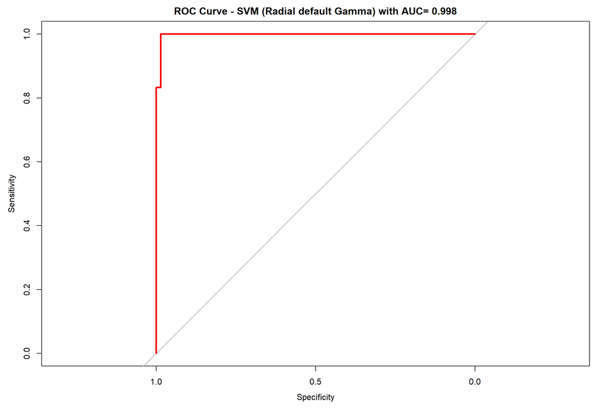

```r
## create ROC curve and AUC
# Ensure binary outcome = 0/1 → convert to factor
df_pc1_svm <- data.frame(df_pc1, outcome = factor(outcome, levels = c(0, 1)))
# get predictive probabilities
svm3.1 <- svm(outcome ~., df_pc1_svm, kernel="radial", probability = TRUE)
svm_pred <- predict(svm3.1, df_pc1, probability = TRUE)
# extract probability of the positive class (tumor)
svm_prob <- attr(svm_pred, "probabilities")[,2]

# create ROC
roc_svm <- roc(outcome, svm_prob)
# get AUC
auc_svm <- auc(roc_svm)
# create plot
plot(roc_svm,
     col = "red",
     lwd = 3,
     main = paste("ROC Curve - SVM (Radial default Gamma) with AUC=", round(auc_svm, 3))
     )
```

**Discussion:**  
SVM results using linear, radial with default gamma, and radial with gamma=0.1, yielded the same result of 99.3% accuracy. SVM performance is consistent with previous models (logistic, NN). The gene expression data are strongly discriminative, requiring minimal model complexity. The best model using kernel = radial at gamma = 1, achieves perfect separation but should be validated with cross-validation or an external test set to ensure it’s not overfitting. The gene expression pattern defined by PC1 genes already forms a straight boundary that separates tumor and normal samples. The results of the performance equality using radial kernels indicates that the nonlinear flexibility isn’t necessary, but doesn’t hurt either. The fact that accuracy remains unchanged suggests that even smooth decision surfaces can still separate the two classes well, another sign that the classes are robustly separable.  
There is a slight drop in accuracy to 97.9% with polynomial kernel, with a small loss in sensitivity (~97%) – this suggests that adding polynomial complexity did not help. The polynomial kernel introduces higher-order terms, creating curved decision boundaries; However, as we have seen with other kernels, the data doesn’t need polynomial transformation because high performance is already achieved with linear separation. On the other hand, the radial kernel model with gamma=1 achieved a perfect classification. Increasing the gamma allows the kernel to form tighter, more complex boundaries around data points.  
The small gain achieved from 99.3% to 100% suggest that the underlying biological signal is largely linear, not non-linear and complex.

## 3.4 Random Forest

```r
library(randomForest)

cross.validate=function(predictor,formula,data=NULL,
                        method="random", N=1000, n.out=5,...) {
  if ( is.null(data) ) { stop("data must be specified") }
  f.str = deparse(formula)
  dependent.name = sub("\\s*~.*","",f.str)
  if ( ! dependent.name %in% names(data) ) {
    dependent.data = get(dependent.name,envir=environment(formula))
    data=cbind(dependent.data,data)
    names(data)[1] = dependent.name
  } else {
    ind = match(dependent.name,names(data))
    data = cbind( data[,ind,drop=F],data[,-ind,drop=F] ) }
  truth = data[,dependent.name]
  truth = truth[0]
  prediction=numeric()
  for ( i in 1:N ) {
    leave.out = sample(nrow(data),size=n.out)
    training.data = data[-leave.out,,drop=F]
    test.data = data[leave.out,,drop=F]
    predictor$train(formula , data=training.data,...)
    pred=predictor$predict(test.data[,-1,drop=F])
    truth[ (length(truth)+1):(length(truth)+n.out) ] =
      test.data[,dependent.name]
    prediction = c(prediction, pred) }
  list(truth=truth,prediction=prediction)  }


do.check=function(data,model) {
  if ( is.null(data) ) { stop("New data must be specified") }
  if ( is.null(model) ) {
    stop("The model has not been trained yet!") } }


# perform random forest analysis
rf1 <- randomForest(outcome ~ ., df_pc1, mtry=20, importance=TRUE, na.action="na.exclude")
rf1
```

```
##
## Call:
##  randomForest(formula = outcome ~ ., data = df_pc1, mtry = 20,      importance = TRUE, na.action = "na.exclude")
##                Type of random forest: classification
##                      Number of trees: 500
## No. of variables tried at each split: 20
##
##         OOB estimate of  error rate: 2.08%
## Confusion matrix:
##    0  1 class.error
## 0 70  2  0.02777778
## 1  1 71  0.01388889
```

```r
rf2 <- randomForest(outcome ~ ., df_pc1+df_pc2, importance=TRUE, na.action="na.exclude")
rf2
```

```
##
## Call:
##  randomForest(formula = outcome ~ ., data = df_pc1 + df_pc2, importance = TRUE,      na.action = "na.exclude")
##                Type of random forest: classification
##                      Number of trees: 500
## No. of variables tried at each split: 4
##
##         OOB estimate of  error rate: 9.72%
## Confusion matrix:
##    0  1 class.error
## 0 68  4  0.05555556
## 1 10 62  0.13888889
```

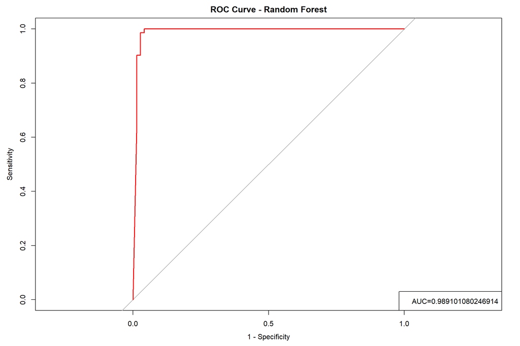

```r
# create ROC curve and get AUC
# predict probabilities (not classes)
rf1_prob <- predict(rf1, type = "prob")[,2]
# compute ROC
roc_rf1 <- roc(outcome, rf1_prob)
# get AUC
auc_rf1 <- auc(roc_rf1)
# plot the ROC curve
plot(roc_rf1,
     col = "red",
     lwd = 2,
     main = "ROC Curve - Random Forest",
     legacy.axes = TRUE)
legend("bottomright",
       legend = paste0("AUC=", auc_rf1))
```

## 3.5 Cross-Validation of Logistic Regression Model

The logistic regression model achieved perfect (100%) accuracy. To check for overfitting, the code below will perform cross-validation.

```r
library(e1071)

do.check=function(data,model) {
  if ( is.null(data) ) { stop("New data must be specified") }
  if ( is.null(model) ) {
    stop("The model has not been trained yet!")
  } }


##Logistic Regression Predictor##
predictor.LR = list(
  model = NULL,
  train = function(f,data,...) {
    predictor.LR$model <<- glm(f, data,
                               family="binomial",na.action="na.exclude",...)  },
  predict=function(newdata=NULL) {
    do.check(newdata,predictor.LR$model)
    as.numeric(
      predict(predictor.LR$model,newdata,type="response") > 0.5
    ) } )


##Cross-validation Function##
cross.validate=function(predictor, formula, data=NULL,
                        method="random", N=1000, n.out=5,...) {
  if (is.null(data)) { stop("data must be specified") }
  f.str = deparse(formula)
  dependent.name = sub("\\s*~.*", "", f.str)
  if (!dependent.name %in% names(data)) {
    dependent.data = get(dependent.name, envir=environment(formula))
    data = cbind(dependent.data, data)
    names(data)[1] = dependent.name
  } else {
    ind = match(dependent.name, names(data))
    data = cbind(data[, ind, drop=F], data[, -ind, drop=F])
  }
  truth = data[, dependent.name]
  truth = truth[0]
  prediction = numeric()
  for (i in 1:N) {
    leave.out = sample(nrow(data), size=n.out)
    training.data = data[-leave.out, , drop=F]
    test.data = data[leave.out, , drop=F]
    predictor$train(formula, data=training.data, ...)
    pred = predictor$predict(test.data[,-1, drop=F])
    truth[(length(truth)+1):(length(truth)+n.out)] = test.data[, dependent.name]
    prediction = c(prediction, pred)
  }
  list(truth=truth, prediction=prediction)
}


##Logistic Regression Cross-validation using df_pc1 dataset##
set.seed(123)

# Train and test within the same data (initial fit)
predictor.LR$train(outcome ~ . , df_pc1[1:20])
assess.prediction(outcome, predictor.LR$predict(df_pc1[1:20]))
```

```
## Total cases that are not NA: 144
## Correct predictions (accuracy): 144(100%)
## TPR (sensitivity)=TP/P: 100%
## TNR (specificity)=TN/N: 100%
## PPV (precision)=TP/(TP+FP): 100%
## FDR (false discovery)=1-PPV: 0%
## FPR =FP/N=1-TNR: 0%
```

```r
# Cross-validation
cv.LR=cross.validate(predictor.LR, outcome ~ . , df_pc1[1:20])
assess.prediction(cv.LR$truth,cv.LR$prediction)
```

```
## Total cases that are not NA: 5000
## Correct predictions (accuracy): 4677(93.5%)
## TPR (sensitivity)=TP/P: 92.7%
## TNR (specificity)=TN/N: 94.4%
## PPV (precision)=TP/(TP+FP): 94.4%
## FDR (false discovery)=1-PPV: 5.58%
## FPR =FP/N=1-TNR: 5.64%
```

**Discussion:**  
The logistic regression model perfectly classified all 144 samples, both tumor and normal samples. This is *apparent* accuracy and perfect performance can be a sign of overfitting, especially with high-dimensional gene expression data. Cross-validation was performed and repeated randomly 1000 times with 5 hold-out samples, for a total 5000 predictions. The model achieved 93.5% accuracy, which is a sign that the model did slightly overfit.